# Realinhamento de Preços

Merenda Escolar

Laboratório Analytics

O gasto do dinheiro público é, para a maioria dos cidadãos, um processo confuso e complexo. No entanto, compreender como se desenrola esse método pode ser fundamental tanto para termos noção de como o nosso dinheiro é gasto quanto para identificarmos gastos fora do padrão.

Este relátório busca compreender o processo de gasto do dinheiro público, a execução orçamentária, e responder questões como: Qual a variação entre o valor licitado e o valor efetivamente pago ao fornecedor de merenda? O quanto variam os valores entre os estágios consecutivos do processo de execução orçamentária?

Para tal, decidimos estudar as compras de merenda na Paraíba no período de 2011 à 2015. Foram analisados dados de 872 licitações, em conjunto com os dados de interesse de seus respectivos empenhos, contratos, liquidações, pagamentos, além dos valores de aditivos e de estorno de cada um dos estágios citados.

## Execução Orçamentária

De acordo com o site do Tesouro Nacional [[1](http://www.tesouro.fazenda.gov.br/execucao-orcamentaria)] a execução orçamerntária ocorre paralelamente à execução financeira e compreende na utilização dos créditos consignados na Lei Orçamentária Anual (LOA). Executar o orçamento é, portanto, realizar as despesas públicas nele previstas, seguindo à risca os três estágios da execução de despesas previstos na Lei nº 4320/64: empenho, liquidação e pagamento.

### Empenho

O empenho é o primeiro estágio da despesa e pode ser conceituado como sendo o ato emanado de autoridade competente que cria para o Estado a obrigação de pagamento, pendente ou não, de implemento de condição, ou seja, é a garantia de que foi feita a reserva orçamentária necessária para o pagamento do que esta sendo contratado. [[1](http://www.tesouro.fazenda.gov.br/execucao-orcamentaria)], [[2](https://www.pjf.mg.gov.br/subsecretarias/controle_interno/documentos/treinamento/05_execucao_ABRIL_2013.pdf)]

O empenho deve sempre anteceder a realização de qualquer despesa, o que implica que este deve ser feito antes ou contemporâneo à assinatura do contrato. [[3](http://www.zenite.blog.br/quando-deve-ser-realizado-o-empenho/)]

### Liquidação

O segundo estágio da despesa pública é a liquidação, que consiste na verificação do direito adquirido pelo credor, tendo por base os títulos e documentos comprobatórios do respectivo crédito, ou seja, é a comprovação de que o credor cumpriu todas as obrigações constantes do empenho. A finalidade é reconhecer ou apurar a origem e o objeto do que se deve pagar, a importância exata a pagar e a quem se deve pagar para extinguir a obrigação. [[1](http://www.tesouro.fazenda.gov.br/execucao-orcamentaria)]

### Pagamento

O último estágio da despesa é o pagamento e consiste na entrega de numerário ao credor do Estado, extinguindo dessa forma o débito ou obrigação. [[1](http://www.tesouro.fazenda.gov.br/execucao-orcamentaria)]

## Comparando os valores entre os estágios da execução orçamentária

### Valor da licitação versus valor do contrato

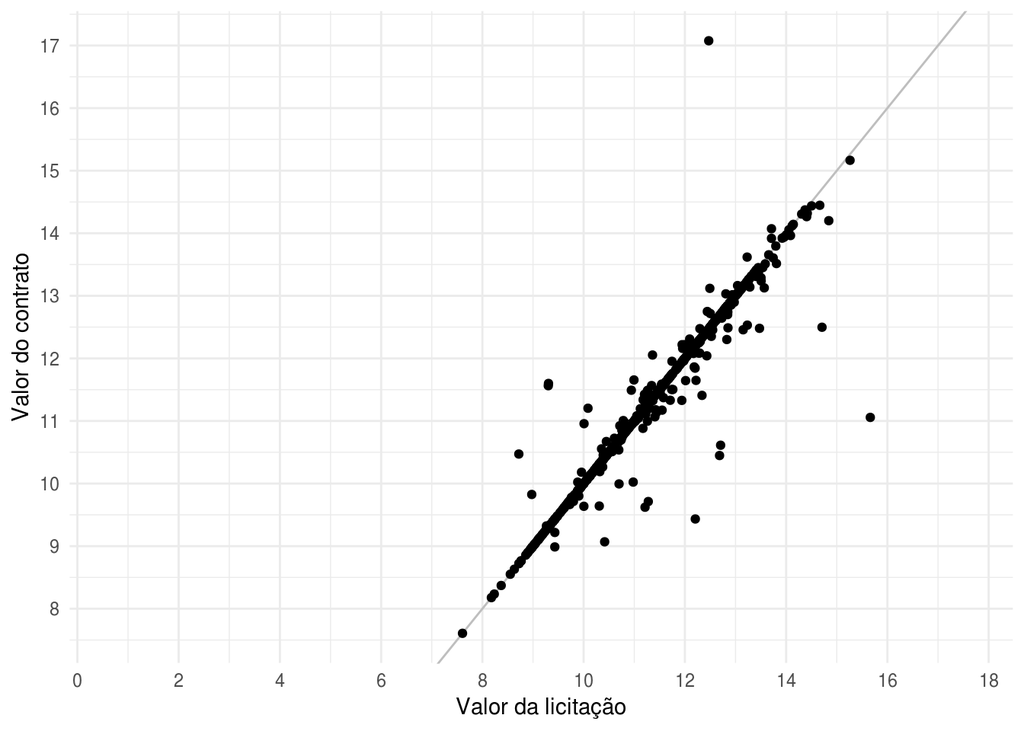

### Valor do contrato versus valor do empenho

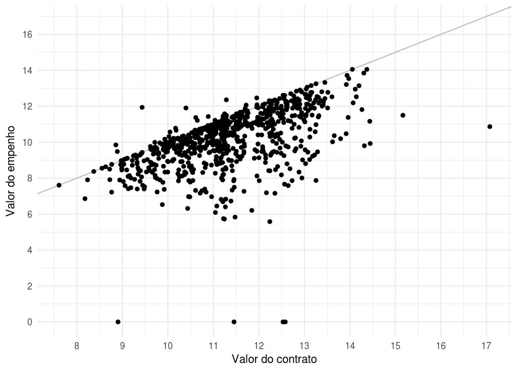

Podemos perceber que na maioria dos casos o valor contratado é superior ao valor empenhado, isso indica que está sendo reservado menos dinheiro do que seria, a príncípio, necessário para fazer face à despesa contratada.

### Valor do empenho versus valor da liquidação

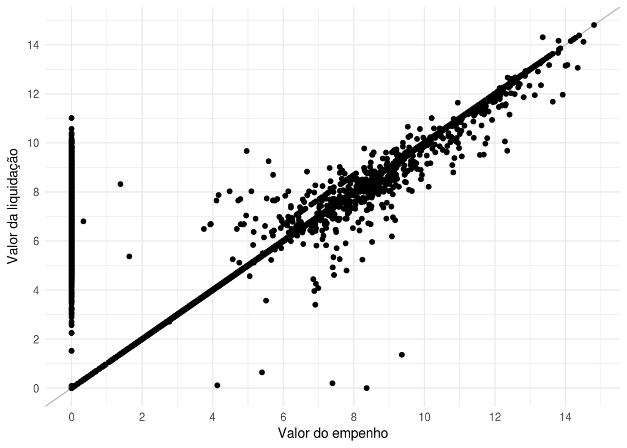

Comparativamente à relação anterior, esta apresenta mais dados em conformidade com o esperado, visto que há uma concentração maior de observações sobre a reta traçada. Essa identifica os casos em que o valor do empenho é exatamente igual ao valor da liquidação.

### Valor da liquidação versus valor do pagamento

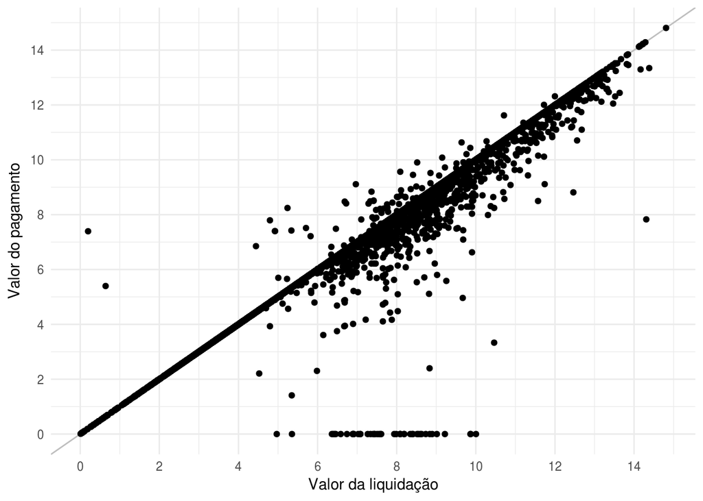

Verificamos aqui que os valores de liquidação e pagamento são, em sua maioria, bem parecidos. Contudo, ao contrário do caso anterior, neste a distribuição em torno da reta não é balanceada, sendo mais comum que o valor do pagamento seja menor que o da liquidação do que o inverso.

Com isso, compreende-se que na grande maioria das vezes está sendo liquidado exatamente o necessário para realizar o pagamento ao fornecedor e, quando isso não é verdade, ocorre que é liquidado um valor maior que do que é realmente pago.

### Outras relações

Abaixo, pode-se ver os gráficos de dispersão entre as variáveis estudadas e o valor da correlação entre elas, assim como suas distribuições isoladas na diagonal.

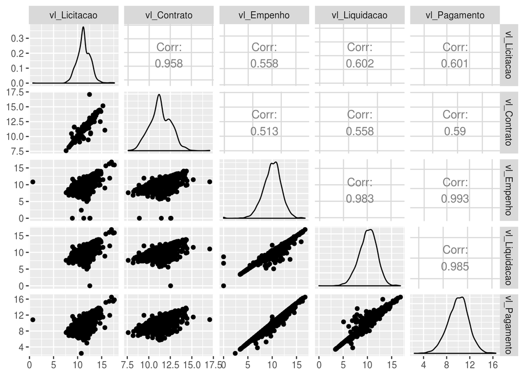

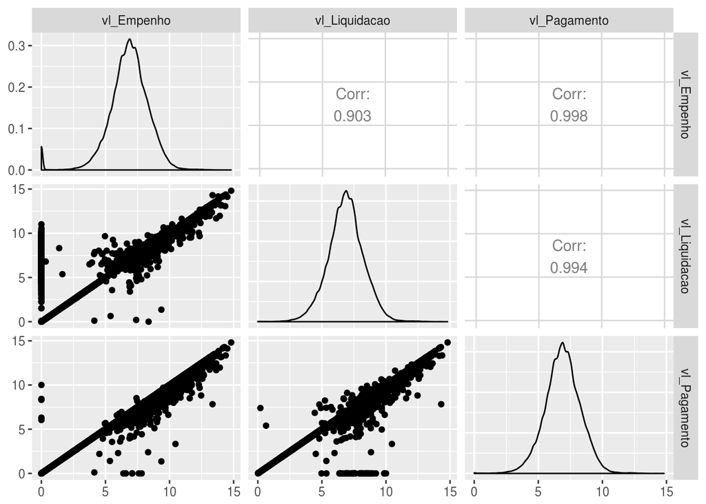

Observando os gráficos de dispersão, é possível identificar dois grupos com valores internos relativamente parecidos: os valores da licitação e do contrato, e os valores do empenho, da liquidação e do pagamento. Essa conclusão parte do fato de que tais gráficos se aproximam de uma reta entre as variáveis de cada grupo.

### Visão geral

O gráfico abaixo apresenta um panorama de como se comportam as licitações ao longo de todo o processo de execução da despesa, considerando também o valor licitado e o valor contratado.

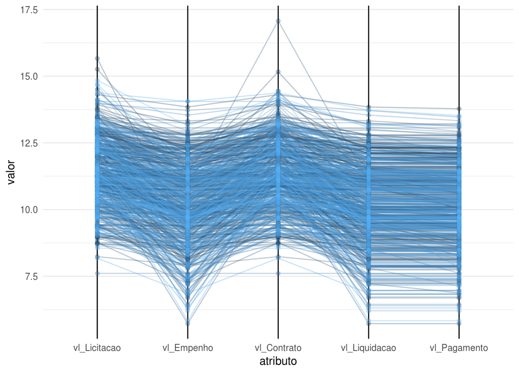

A visualização nos permite observar variações constantes entre as fases do processo em análise, tanto de aumento quanto de redução de valor.

Uma variável que influencia essa variação é o valor do contrato, pois ao contrário do esperado ele é bem diferente do valor empenhado. Por outro lado os valores observados de empenho, liquidação e pagamento variam bem menos entre si.

Para compreendermos melhor o resultado deste “sobe e desce” de valores decidimos comparamos o valor de empenhos, que representa o valor que o governo pretendia e estava preparado para gastar, com o valor dos pagamentos, que refletem o valor efetivamente pago ao fornecedor.

### Valor do empenho versus valor da pagamento

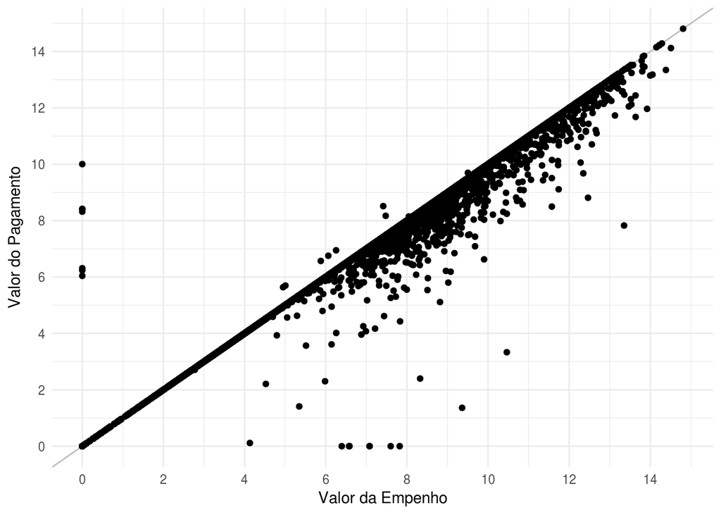